# EDA of Happy DB

### Load libraries…

```r
library(tidyverse)
library(tidytext)
library(DT)
library(scales)
library(wordcloud2)
library(gridExtra)
library(ngram)
library(shiny)
library(forcats)
library(sentimentr)
library(ggthemes)
```

### Load data needed…

```r
hm_data <- read_csv("../output/processed_moments.csv")

urlfile<-'https://raw.githubusercontent.com/rit-public/HappyDB/master/happydb/data/demographic.csv'
demo_data <- read_csv(urlfile)

entertainment_topic <- read.csv('https://raw.githubusercontent.com/rit-public/HappyDB/master/happydb/data/topic_dict/entertainment-dict.csv', header = FALSE)

exercise <- read.csv('https://raw.githubusercontent.com/rit-public/HappyDB/master/happydb/data/topic_dict/exercise-dict.csv', header = FALSE)

family <- read.csv('https://raw.githubusercontent.com/rit-public/HappyDB/master/happydb/data/topic_dict/family-dict.csv', header = FALSE)

food <- read.csv('https://raw.githubusercontent.com/rit-public/HappyDB/master/happydb/data/topic_dict/food-dict.csv', header = FALSE)

people <- read.csv('https://raw.githubusercontent.com/rit-public/HappyDB/master/happydb/data/topic_dict/people-dict.csv', header = FALSE)

pets <- read.csv('https://raw.githubusercontent.com/rit-public/HappyDB/master/happydb/data/topic_dict/pets-dict.csv', header = FALSE)

school <- read.csv('https://raw.githubusercontent.com/rit-public/HappyDB/master/happydb/data/topic_dict/school-dict.csv', header = FALSE)

shopping <- read.csv('https://raw.githubusercontent.com/rit-public/HappyDB/master/happydb/data/topic_dict/shopping-dict.csv', header = FALSE)

work <- read.csv('https://raw.githubusercontent.com/rit-public/HappyDB/master/happydb/data/topic_dict/work-dict.csv', header = FALSE)
```

### Explore

#### When people are talking about happiness, what are they really talking about?

now pre-process data. For hm_data it’s the same as in HappyDB_RShiny.Rmd. Then I assign each sentence a category based on dictionaries available from HappyDB’s Github

```r
hm_data <- hm_data %>%
  inner_join(demo_data, by = "wid") %>%
  select(wid,
         original_hm,
         gender,
         marital,
         parenthood,
         reflection_period,
         age,
         country,
         ground_truth_category,
         text) %>%
  mutate(count = sapply(hm_data$text, wordcount)) %>%
  filter(gender %in% c("m", "f")) %>%
  filter(marital %in% c("single", "married")) %>%
  filter(parenthood %in% c("n", "y")) %>%
  filter(reflection_period %in% c("24h", "3m")) %>%
  mutate(reflection_period = fct_recode(reflection_period,
                                        months_3 = "3m", hours_24 = "24h"))

data_with_row_no <- hm_data %>%
  mutate(sentense_id = row_number())

data <- data_with_row_no %>%
  unnest_tokens(word, text)

# classify each word to each different category
data <- data %>%
  mutate(is_entertainment = word %in% entertainment_topic$V1) %>%
  mutate(is_exercise = word %in% exercise$V1) %>%
  mutate(is_family = word %in% family$V1) %>%
  mutate(is_food = word %in% food$V1) %>%
  mutate(is_people = word %in% people$V1) %>%
  mutate(is_pets = word %in% pets$V1) %>%
  mutate(is_school = word %in% school$V1) %>%
  mutate(is_shopping = word %in% shopping$V1) %>%
  mutate(is_work = word %in% work$V1)

sentence_categories <- data %>%
  group_by(sentense_id) %>%
  summarise(entertainment = sum(is_entertainment) > 0, exercise = sum(is_exercise)>0, family = sum(is_family)>0, food = sum(is_food)>0, people =sum(is_people)>0,pets=sum(is_pets)>0, school = sum(is_school)>0, shopping = sum(is_shopping)>0, work = sum(is_work)>0)

# now recombine sentences with hm_data
data_with_categories <- data_with_row_no%>%
  inner_join(sentence_categories, by = "sentense_id")

data_with_categories <- data_with_categories %>%
  mutate(has_category = exercise + family+food+people+pets+school+shopping+work)
```

check how much percentage of sentences in this database can be categorized using categories given by HappyDB

```r
with_categories <- data_with_categories %>%
  filter(has_category > 0)
nrow(with_categories)/nrow(data_with_categories)
```

```
## [1] 0.6980988
```

That’s a fair amount of samples.. explore further using this subset. Others that don’t have a category probably due to the small dictionaries given by HappyDB. Might be other better ways to capture the category. Let’s look at how these categories are distributed. Notice that one sentence might have multiple categories.

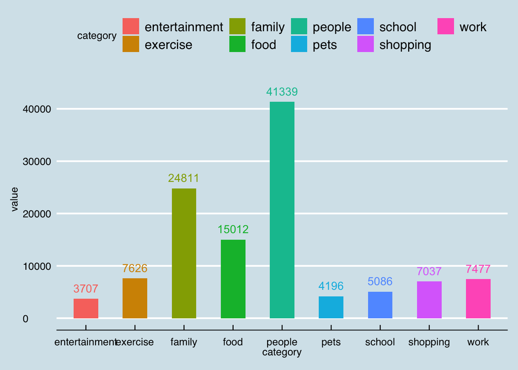

```r
categories_distribution <- data.frame(entertainment = sum(with_categories$entertainment), exercise = sum(with_categories$exercise), family = sum(with_categories$family),food = sum(with_categories$food),people = sum(with_categories$people),pets = sum(with_categories$pets),school = sum(with_categories$school),shopping = sum(with_categories$shopping),work = sum(with_categories$work))

categories_distribution <- categories_distribution %>%
  gather("category", "value", 1:9)

categories_distribution %>%
  ggplot(aes(x = category, y=value, fill=category)) +
  geom_bar(stat = "identity", width = 0.5) +
  theme_economist() +
  geom_text(aes(label = value, vjust = -0.8, hjust = 0.5, color = category), show_guide = FALSE) +
  ylim(min(categories_distribution$value, 0)*1.1, max(categories_distribution$value)*1.1)
```

Happiness definitely more strongly related to people & family. Let’s see some examples of the people category. Basically it’s something about the other people.

```r
ppl <- with_categories %>%
  filter(people)
head(ppl$original_hm)
```

```
## [1] "I was happy when my son got 90% marks in his examination"
## [2] "We had a serious talk with some friends of ours who have been flaky lately. They understood and we had a good evening hanging out."
## [3] "I got gift from my elder brother which was really surprising me"
## [4] "YESTERDAY MY MOMS BIRTHDAY SO I ENJOYED"
## [5] "Watching cupcake wars with my three teen children"
## [6] "went to movies with my friends it was fun"
```

#### are there geographical difference for these categories..?

```r
top_ten <- with_categories %>%
  group_by(country) %>%
  summarise(count = n()) %>%
  arrange(desc(count)) %>%
  mutate(rank = row_number()) %>%
  filter(rank <= 10)

top_five <- top_ten %>%
  filter(rank <= 5)
```

Seems like in this dataset a majority of people is from the US. So we will just look at the percentage for the top 5 countries.

```r
mekko_graph <- with_categories %>%
  group_by(country) %>%
  summarise(entertainment = sum(entertainment), exercise = sum(exercise), family = sum(family), food=sum(food), people=sum(people), pets=sum(pets), school=sum(school), shopping=sum(shopping), work=sum(work)) %>%
  filter(country %in% top_five$country)

mekko_graph <- mekko_graph %>%
  mutate(total = entertainment+exercise+family+food+people+pets+school+shopping+work) %>%
  mutate(entertainment = round(entertainment / total,digits=3)*100,exercise = round(exercise / total,digits=3)*100, family = round(family / total,digits=3)*100,food = round(food / total,digits=3)*100,people = round(people / total,digits=3)*100,pets = round(pets / total,digits=3)*100,school = round(school / total,digits=3)*100,shopping = round(shopping / total,digits=3)*100,work = round(work / total,digits=3)*100)

mekko_graph$total <- NULL
mekko_graph
```

```
## # A tibble: 5 x 10
##   country entertainment exercise family  food people  pets school shopping
##   <chr>           <dbl>    <dbl>  <dbl> <dbl>  <dbl> <dbl>  <dbl>    <dbl>
## 1 CAN               4.7      6.4   12.7  19.2   34.3   5.4    3.1      6
## 2 GBR               5       14.4   14.1  18.5   32.3   5      2.6      4.7
## 3 IND               2.9      4.7   24.8   6.7   39     1.3    6.1      7.5
## 4 USA               3.2      7.    20.7  14.4   34.7   4.2    3.9      5.6
## 5 VEN               6.1      6.7   20    13.1   34.9   1.8    5.4      6
## # ... with 1 more variable: work <dbl>
```

#### What about the influence of gender, marital status, parenthood, reflection_period, age?

```r
create_mekko_table <- function(data, factors) {
  mekko_graph <-  data %>%
  group_by_(factors) %>%
  summarise(entertainment = sum(entertainment), exercise = sum(exercise), family = sum(family), food=sum(food), people=sum(people), pets=sum(pets), school=sum(school), shopping=sum(shopping), work=sum(work))
  mekko_graph <- mekko_graph %>%
  mutate(total = entertainment+ exercise+family+food+people+pets+school+shopping+work) %>%
  mutate(entertainment = round(entertainment / total,digits=3)*100, exercise = round(exercise / total,digits=3)*100, family = round(family / total,digits=3)*100,food = round(food / total,digits=3)*100,people = round(people / total,digits=3)*100,pets = round(pets / total,digits=3)*100,school = round(school / total,digits=3)*100,shopping = round(shopping / total,digits=3)*100,work = round(work / total,digits=3)*100)

mekko_graph$total <- NULL
return(mekko_graph)
}
create_mekko_table(with_categories,'gender')
```

```
## # A tibble: 2 x 10
##   gender entertainment exercise family  food people  pets school shopping
##   <chr>          <dbl>    <dbl>  <dbl> <dbl>  <dbl> <dbl>  <dbl>    <dbl>
## 1 f                2.9      4.9   24.4  11.8   36.8   3.8    4.3      5.5
## 2 m                3.4      7.9   18.9  13.8   34.5   3.4    4.5      6.5
## # ... with 1 more variable: work <dbl>
```

```r
create_mekko_table(with_categories, 'marital')
```

```
## # A tibble: 2 x 10
##   marital entertainment exercise family  food people  pets school shopping
##   <chr>           <dbl>    <dbl>  <dbl> <dbl>  <dbl> <dbl>  <dbl>    <dbl>
## 1 married           2.8      5.5   27.2  10.8   36.2  2.8     3.8      5.3
## 2 single            3.6      7.6   15.4  15     34.9  4.40    5        6.8
## # ... with 1 more variable: work <dbl>
```

```r
create_mekko_table(with_categories, 'parenthood')
```

```
## # A tibble: 2 x 10
##   parenthood entertainment exercise family  food people  pets school
##   <chr>              <dbl>    <dbl>  <dbl> <dbl>  <dbl> <dbl>  <dbl>
## 1 n                    3.5      7.4   16.1  15.4   34.2   4.7    4.5
## 2 y                    2.8      5.5   27.8   9.8   37.2   2.3    4.2
## # ... with 2 more variables: shopping <dbl>, work <dbl>
```

```r
create_mekko_table(with_categories, 'reflection_period')
```

```
## # A tibble: 2 x 10
##   reflection_peri… entertainment exercise family  food people  pets school
##   <fct>                    <dbl>    <dbl>  <dbl> <dbl>  <dbl> <dbl>  <dbl>
## 1 hours_24                   3.4      7.    20.5  15.7   34.7   3.8    3.5
## 2 months_3                   3        6.2   22.1  10.3   36.4   3.5    5.2
## # ... with 2 more variables: shopping <dbl>, work <dbl>
```

```r
with_categories %>%
  group_by(age) %>%
  summarise(count = n()) %>%
  arrange(desc(count))
```

```
## # A tibble: 129 x 2
##    age   count
##    <chr> <int>
##  1 29     2912
##  2 26     2687
##  3 25     2634
##  4 27     2535
##  5 30     2376
##  6 28     2374
##  7 31     2104
##  8 24     1958
##  9 32     1945
## 10 23     1867
## # ... with 119 more rows
```

I will use 22 as a bar here, then 23~40, above 40

```r
age_range <- with_categories %>%
  mutate(age_range = ifelse(age <= 22, 'below 22', ifelse(age <=40, 'below 40 but greater than 22', 'greater than 40')))
create_mekko_table(age_range, 'age_range')
```

```
## # A tibble: 4 x 10
##   age_range entertainment exercise family  food people  pets school
##   <chr>             <dbl>    <dbl>  <dbl> <dbl>  <dbl> <dbl>  <dbl>
## 1 below 22            3.7      6.7   15.3  13.3   35.6   3.6    9.6
## 2 below 40…           3.2      6.6   21    13     35.8   3.5    3.9
## 3 greater …           2.7      6.4   25.7  12.4   34.6   4.2    4.1
## 4 <NA>                0       11.4   20.5   9.1   31.8   2.3   11.4
## # ... with 2 more variables: shopping <dbl>, work <dbl>
```

still no obvious conclusion.

We also have the word count at hand. Wondering for different categories, are there any difference in terms of the number of words they used? For example I assume when it comes to family, people will talk more while for entertainment, people will say less, like a simple sentence:“nintendo is fun!”

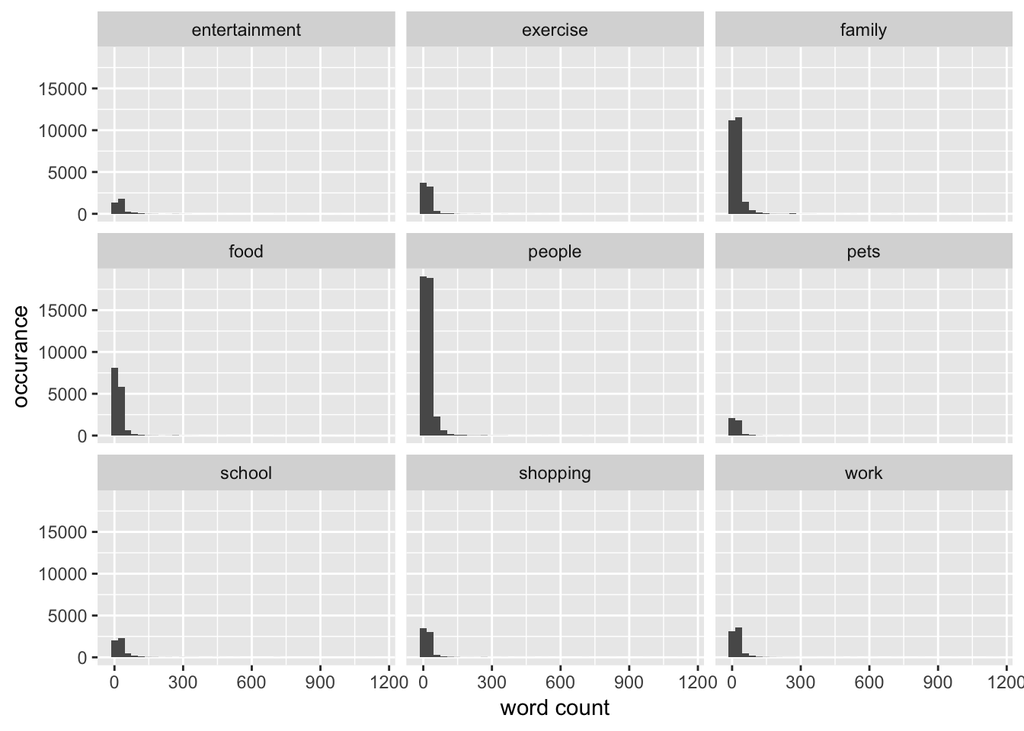

```r
word_count_data <- with_categories %>%
  mutate(word_count = sapply(with_categories$original_hm, wordcount))

generate_category_wordcount_data <- function(data, cat) {
  dt <- data %>%
  filter_(cat) %>%
  mutate(category = cat) %>%
    select(category, word_count)
  return(dt)
}

word_count <- rbind(generate_category_wordcount_data(word_count_data, 'entertainment'),
                    generate_category_wordcount_data(word_count_data,'exercise'),
                    generate_category_wordcount_data(word_count_data,'family'),
                    generate_category_wordcount_data(word_count_data,'food'),
                    generate_category_wordcount_data(word_count_data,'people'),
                    generate_category_wordcount_data(word_count_data,'pets'),
                    generate_category_wordcount_data(word_count_data,'school'),
                    generate_category_wordcount_data(word_count_data,'shopping'),
                    generate_category_wordcount_data(word_count_data,'work'))
word_count %>%
  ggplot(aes(x = word_count)) +
  geom_histogram(bins=40) +
  facet_wrap(~ category) +
  xlab("word count") +
  ylab("occurance")
```

No apparent results.. but who’s writing that many words??

```r
word_count_data %>%
  filter(word_count > 1000) %>%
  select(original_hm)
```

```
## # A tibble: 3 x 1
##   original_hm
##   <chr>
## 1 "This is the second essay in a two-part series about my journey to visit…
## 2 "This is the second essay in a two-part series about my journey to visit…
## 3 "My much awaited desired prolonged Velankanni trip.\r\n\r\nOne of the gr…
```

Ok someone is writing an essay about their journey.. try the previous plotting part again by removing outliers

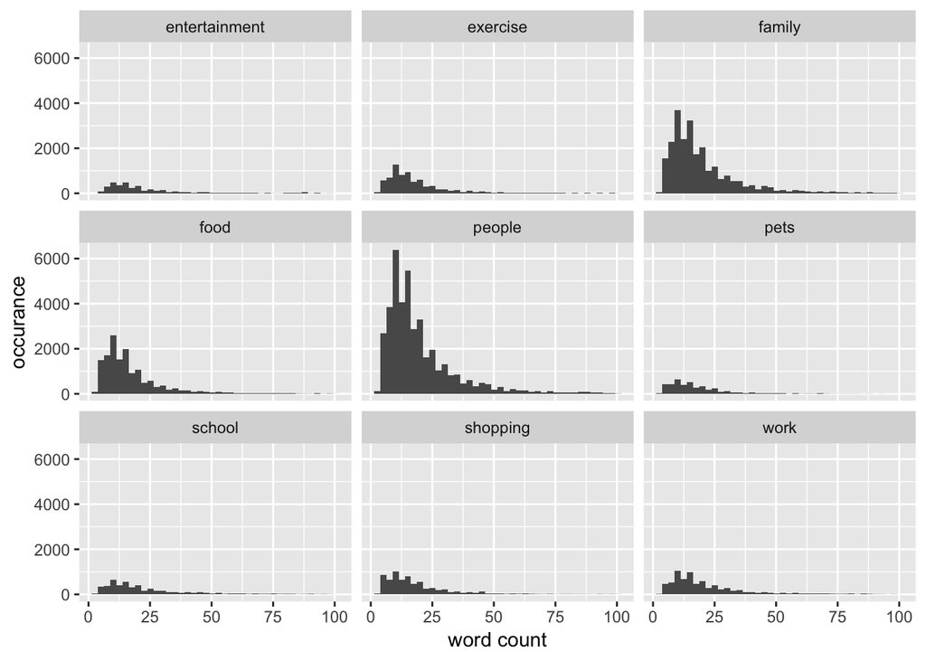

```r
word_count_data <- word_count_data %>%
  filter(word_count <= 100)
word_count <- rbind(generate_category_wordcount_data(word_count_data, 'entertainment'),
                    generate_category_wordcount_data(word_count_data,'exercise'),
                    generate_category_wordcount_data(word_count_data,'family'),
                    generate_category_wordcount_data(word_count_data,'food'),
                    generate_category_wordcount_data(word_count_data,'people'),
                    generate_category_wordcount_data(word_count_data,'pets'),
                    generate_category_wordcount_data(word_count_data,'school'),
                    generate_category_wordcount_data(word_count_data,'shopping'),
                    generate_category_wordcount_data(word_count_data,'work'))
word_count %>%
  ggplot(aes(x = word_count)) +
  geom_histogram(bins=40) +
  facet_wrap(~ category) +
  xlab("word count") +
  ylab("occurance")
```

There’s really not that much difference.